# STAT 240 Discussion 3

### 3

```r
wasps %>%
  count(week,block,position) %>%
  pivot_wider(id_cols=c(week,position), names_from=block,values_from=n, values_fill=0) %>%
  pivot_longer(cols=A:E,names_to="block", values_to="n") %>%
  filter(n != 1)
```

```
## # A tibble: 2 × 4
##    week position block     n
##   <int>    <dbl> <chr> <int>
## 1     2        2 D         0
## 2     2        6 E         2
```

### 4

#### 4A

> Which block/lure combinations do not appear exactly 1 time in a week?

Combine what you learned in the previous exercise and from the output of the code below to determine which week/lure/block/position is in the data set and should not be and which is missing from the data set and should be.

```r
wasps %>%
  select(week,block,lure) %>%
  group_by(week) %>%
  count(block,lure) %>%
  pivot_wider(id_cols=c(week,lure),names_from=block, values_from=n,values_fill=0) %>%
  pivot_longer(cols=A:E,names_to="block",values_to="n") %>%
  filter(n != 1)
```

```
## # A tibble: 2 × 4
## # Groups:   week [1]
##    week lure    block     n
##   <int> <chr>   <chr> <int>
## 1     2 Control D         0
## 2     2 Control E         2
```

#### 4B

> Correct the error.

The following code adds an index with the row number to the wasp data.

(You may want to use `filter()` to find the row with the error. See your responses to the previous question to determine which variables and values to use in the filter.)

```r
wasps <- wasps %>%
  mutate(index = 1:200) %>%
  select(index,everything())
```

## Section B: stringr

#### Create Data Frames

Let’s make some data frames that also have an index variable which is the row number. These will be used in the questions below.

```r
df_words = tibble(
  index = seq_along(stringr::words),
  words = stringr::words
)

df_colors = tibble(
  index = seq_along(colors()),
  colors = colors()
)
```

### 5

The R command `colors()` returns an array with all of the color names that R knows about, which was how the `df_colors` data frame was created. Find all colors that contain the pattern “orange” or “yellow”.

- Print out a data frame that displays the number of colors (that contain the pattern “orange”) and the first and last of these colors alphabetically.

```r
library(stringr)

filtered_colors <- df_colors[str_detect(df_colors$colors, "orange|yellow"), ]
num_orange_colors <- sum(str_detect(filtered_colors$colors, "orange"))
sorted_colors <- filtered_colors[order(filtered_colors$colors), ]
result_df <- data.frame(Number_of_Colors = num_orange_colors,
                        First_Color = sorted_colors$colors[1],
                        Last_Color = sorted_colors$colors[nrow(sorted_colors)])

result_df
```

```
##   Number_of_Colors First_Color  Last_Color
## 1               15  darkorange yellowgreen
```

### 6

How many words in `df_words` begin with each letter? Do not distinguish between lower case and capital letters.

- Make a bar graph that displays these counts (bonus: if you have time, can you figure out how to order the bars from tallest to shortest? The `reorder()` function may be useful here)
- Be sure to label the axes and add a descriptive title.
- Repeat for the last letter of each word.

*Hint: use `mutate()` and `str_sub()` to create new columns with the first and last letter of each word and then make the graphs. Use either `str_to_lower()` or `str_to_upper()` before counting.*

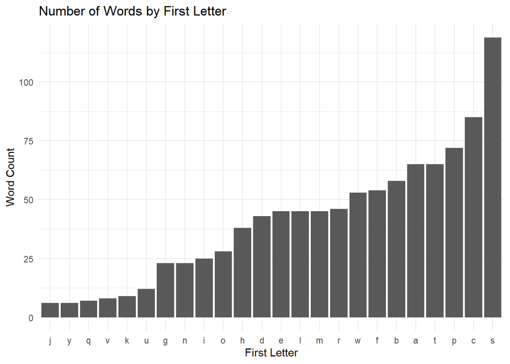

```r
library(ggplot2)
library(dplyr)
library(stringr)

df_words <- df_words %>%
  mutate(first_letter = str_sub(words, 1, 1) %>% str_to_lower())

word_counts <- df_words %>%
  count(first_letter)

word_counts <- word_counts %>%
  mutate(first_letter = reorder(first_letter, n))

ggplot(word_counts, aes(x = first_letter, y = n)) +
  geom_bar(stat = "identity") +
  labs(x = "First Letter", y = "Word Count", title = "Number of Words by First Letter") +
  theme_minimal()
```

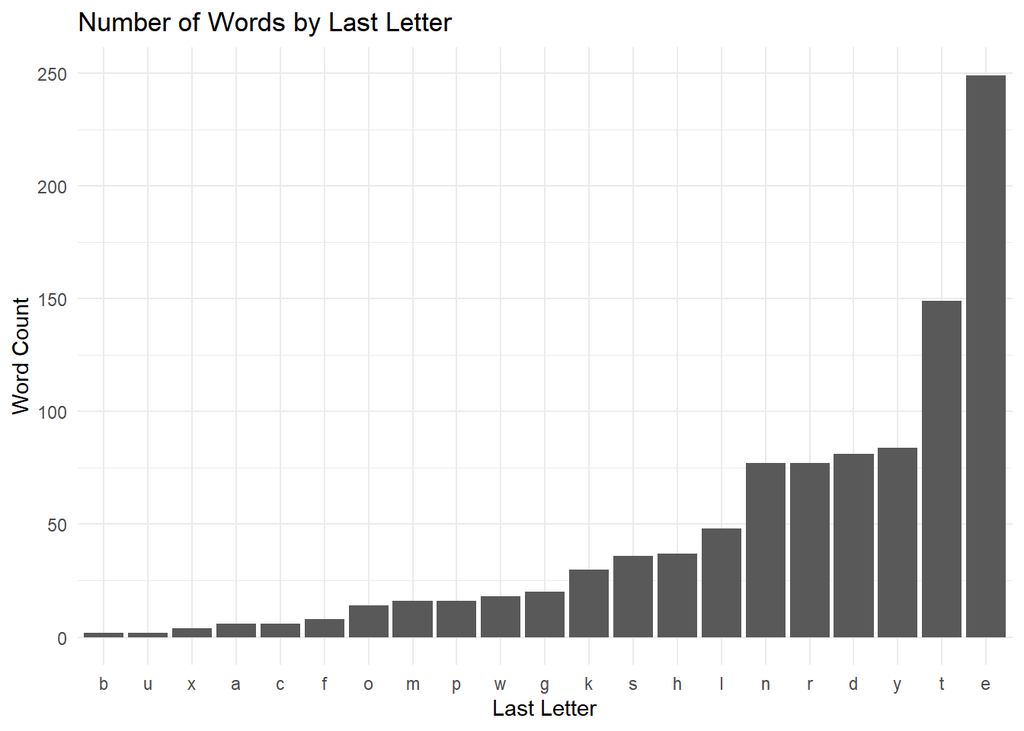

```r
df_words <- df_words %>%
  mutate(last_letter = str_sub(words, -1, -1) %>% str_to_lower())

word_counts_last <- df_words %>%
  count(last_letter)

word_counts_last <- word_counts_last %>%
  mutate(last_letter = reorder(last_letter, n))

ggplot(word_counts_last, aes(x = last_letter, y = n)) +
  geom_bar(stat = "identity") +
  labs(x = "Last Letter", y = "Word Count", title = "Number of Words by Last Letter") +
  theme_minimal()
```

### 7

Find all words in `df_words` that begin with the most frequent first letter and end with the most frequent last letter.

- Print out a data frame that displays the number of such words and the first and last word in alphabetical order.

```r
df_words %>%
  filter(str_detect(words, "^s.*e$")) %>%summarize(count = n(), first_word =min(words), last_word = max(words))
```

```
## # A tibble: 1 × 3
##   count first_word last_word
##   <int> <chr>      <chr>
## 1    35 safe       surprise
```

### 8

Find all colors in `df_colors()` that (i) do not contain digits and (ii) do not begin with the letter “s”. How many such colors are there? Print them out.

```r
#Cannot include a digit. Cannot start with 's'.

df_colors %>%
  filter(!str_detect(df_colors$colors, "1|2|3|4|5|6|7|8|9|0") & str_starts(df_colors$colors, "s", negate = TRUE)) %>%
  print()
```

```
## # A tibble: 130 × 2
##    index colors
##    <int> <chr>
##  1     1 white
##  2     2 aliceblue
##  3     3 antiquewhite
##  4     8 aquamarine
##  5    13 azure
##  6    18 beige
##  7    19 bisque
##  8    24 black
##  9    25 blanchedalmond
## 10    26 blue
## # ℹ 120 more rows
```

-RESPONSE: There are a total of 130 colors whose names do not start with ‘s’ nor contain a digit